# Developing and Testing Movie Recommendation Algorithm

## Part 2: MovieLens Data

1. Load in the training dataset from [here](https://github.com/datasciencelabs/2022/blob/master/data/mv_st.RDS), which can be accessed as `mv_st$train`.

```r
# your code here
mv_st <- readRDS(url("https://github.com/datasciencelabs/2022/raw/master/data/mv_st.RDS"))
```

2. Preprocess the data in any way you find appropriate. This could include removing noninformative features.

```r
mv_train<-as.data.frame(mv_st$train)
as.tibble(mv_train)
```

```
#> # A tibble: 71,801 × 7
#>    movieId title                             year genres userId rating timestamp
#>      <int> <chr>                            <int> <fct>   <int>  <dbl>     <int>
#>  1    1029 Dumbo                             1941 Anima…    348    3      1.26e9
#>  2    1061 Sleepers                          1996 Thril…    348    3      1.26e9
#>  3    1129 Escape from New York              1981 Actio…    348    2      1.26e9
#>  4    1172 Cinema Paradiso (Nuovo cinema P…  1989 Drama     348    4      1.26e9
#>  5    1287 Ben-Hur                           1959 Actio…    348    2      1.26e9
#>  6    1293 Gandhi                            1982 Drama     348    2      1.26e9
#>  7    1339 Dracula (Bram Stoker's Dracula)   1992 Fanta…    348    3.5    1.26e9
#>  8    1343 Cape Fear                         1991 Thril…    348    2      1.26e9
#>  9    1371 Star Trek: The Motion Picture     1979 Adven…    348    2.5    1.26e9
#> 10    1405 Beavis and Butt-Head Do America   1996 Adven…    348    1      1.26e9
#> # ℹ 71,791 more rows
```

```r
mv_test<-as.data.frame(mv_st$test)
as.tibble(mv_test)
```

```
#> # A tibble: 18,265 × 7
#>    movieId title                     year genres         userId rating timestamp
#>      <int> <chr>                    <int> <fct>           <int> <lgl>      <int>
#>  1      31 Dangerous Minds           1995 Drama             348 NA        1.26e9
#>  2    1263 Deer Hunter, The          1978 Drama|War         348 NA        1.26e9
#>  3    2455 Fly, The                  1986 Drama|Horror|…    348 NA        1.26e9
#>  4    2968 Time Bandits              1981 Adventure|Com…    348 NA        1.26e9
#>  5      52 Mighty Aphrodite          1995 Comedy|Drama|…     86 NA        8.35e8
#>  6     168 First Knight              1995 Action|Drama|…     86 NA        8.35e8
#>  7     223 Clerks                    1994 Comedy             86 NA        8.35e8
#>  8     296 Pulp Fiction              1994 Comedy|Crime|…     86 NA        8.35e8
#>  9     349 Clear and Present Danger  1994 Action|Crime|…     86 NA        8.35e8
#> 10     356 Forrest Gump              1994 Comedy|Drama|…     86 NA        8.35e8
#> # ℹ 18,255 more rows
```

```r
mv_train |>
  summarize(n_users = n_distinct(userId),
            n_movies = n_distinct(movieId),
            n_genres=n_distinct(genres))
```

```
#>   n_users n_movies n_genres
#> 1     671     3495      616
```

```r
mv_test |>
  summarize(n_users = n_distinct(userId),
            n_movies = n_distinct(movieId),
            n_genres=n_distinct(genres))
```

```
#>   n_users n_movies n_genres
#> 1     671     3159      588
```

```r
#check whether the userid ,hgenres, movieid in test set are in training set
mv_test|>
  anti_join(mv_train, by = "movieId")
```

```
#> [1] movieId   title     year      genres    userId    rating    timestamp
#> <0 rows> (or 0-length row.names)
```

```r
mv_test|>
  anti_join(mv_train, by = "userId")
```

```
#> [1] movieId   title     year      genres    userId    rating    timestamp
#> <0 rows> (or 0-length row.names)
```

```r
mv_test|>
  anti_join(mv_train, by = "genres")
```

```
#> [1] movieId   title     year      genres    userId    rating    timestamp
#> <0 rows> (or 0-length row.names)
```

We would like to contruct a rating matrix with movie id, userid, and rating

```r
mat <- select(mv_train, movieId, userId, rating) |>
  pivot_wider(names_from = movieId, values_from = rating)
rnames <- mat$userId
mat <- as.matrix(mat[,-1])
rownames(mat) <- rnames
dim(mat)
```

```
#> [1]  671 3495
```

```r
movie_map <- mv_train |> select(movieId, title) |>
  distinct(movieId, .keep_all = TRUE)
```

I would like to the Recommenderlab to build the prediction. So, I would convert the matrix into a realRatingMatrix data structure

```r
movie_r <- as(mat, "realRatingMatrix")
summary(getRatings(movie_r))
```

```
#>    Min. 1st Qu.  Median    Mean 3rd Qu.    Max.
#>    0.50    3.00    4.00    3.58    4.00    5.00
```

```r
#check rating distribution
data.frame(ratings = getRatings(movie_r)) %>%
  ggplot(aes(ratings)) + geom_bar(width = 0.75) +
    labs(title = 'Movielense Ratings Distribution')

#check distributions of the number of reviews given by each user.

summary(rowCounts(movie_r))
```

```
#>    Min. 1st Qu.  Median    Mean 3rd Qu.    Max.
#>      12      28      52     107     120    1159
```

```r
rowCounts(movie_r) %>%
  data.frame(reviews_per_person = .) %>%
  ggplot(aes(x = reviews_per_person)) +
    geom_histogram(aes(y = ..density..), binwidth = 20) +
    scale_y_continuous(limits = c(0,.0125),
                       breaks = seq(0, .0125, by = 0.0025),
                       labels = seq(0, .0125, by = 0.0025)) +
    labs(title = 'Number of Ratings Per MovieLense Reviewer')
#check distributions of the number of   ratings given per movie

colCounts(movie_r) %>%
  data.frame(movie_review_count = .) %>%
  ggplot(aes(x = movie_review_count)) +
    geom_histogram(aes(y = ..density..), binwidth = 20) +
    scale_y_continuous(limits = c(0,.0175)) +
    labs(title = 'Number of Reviews Per MovieLense listed Movie')

#average rating per user
 summary(rowMeans(movie_r))
```

```
#>    Min. 1st Qu.  Median    Mean 3rd Qu.    Max.
#>    1.20    3.40    3.69    3.67    4.00    4.95
```

```r
 rowMeans(movie_r) %>%
  data.frame(ratings_per_person = .) %>%
  ggplot(aes(x = ratings_per_person)) + geom_bar(width = 0.75) +
    labs(title = 'Average Movielense Ratings  per user Distribution')

 #average rating per movie
 summary(colMeans(movie_r))
```

```
#>    Min. 1st Qu.  Median    Mean 3rd Qu.    Max.
#>    0.50    3.06    3.50    3.41    3.85    5.00
```

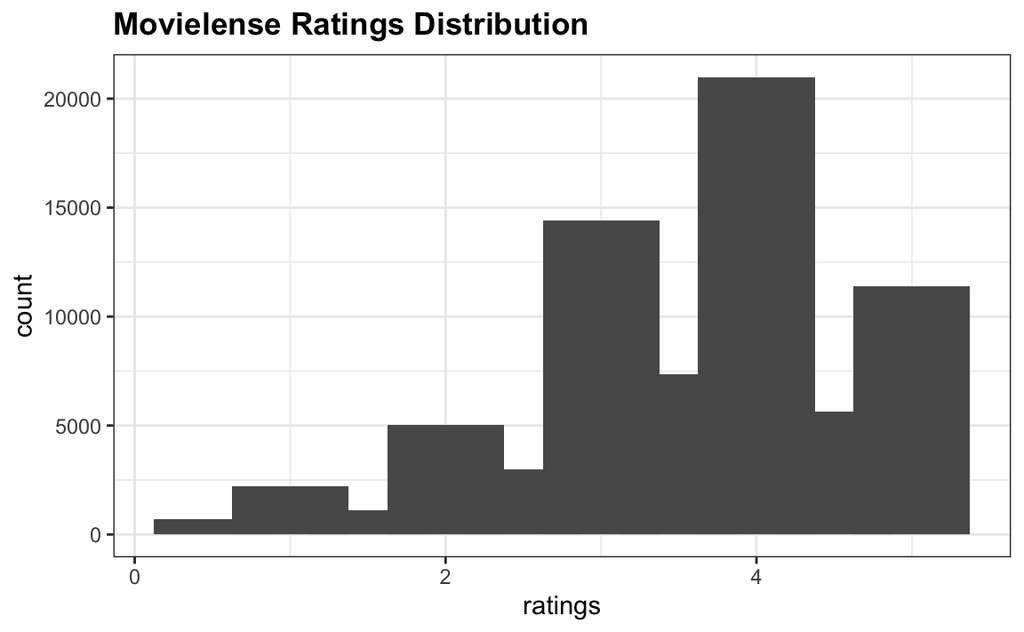

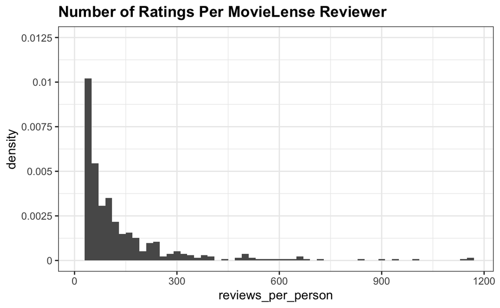

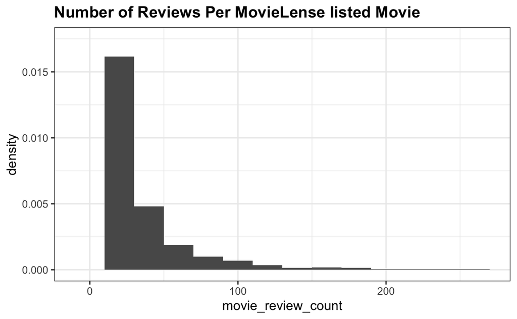

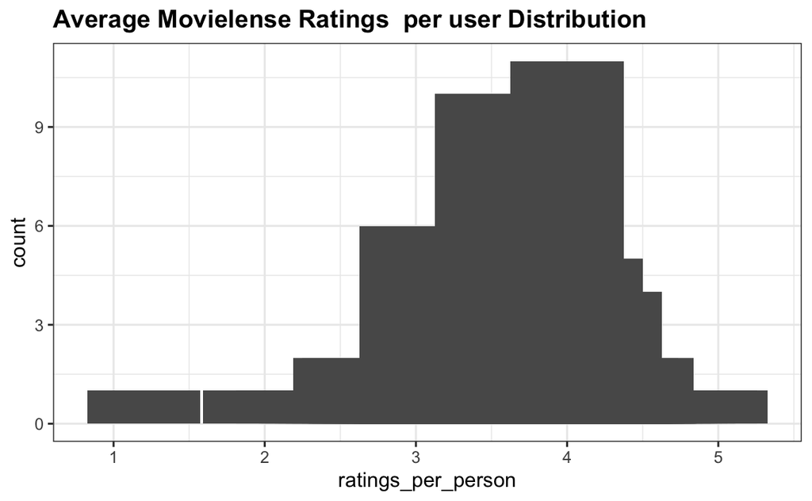

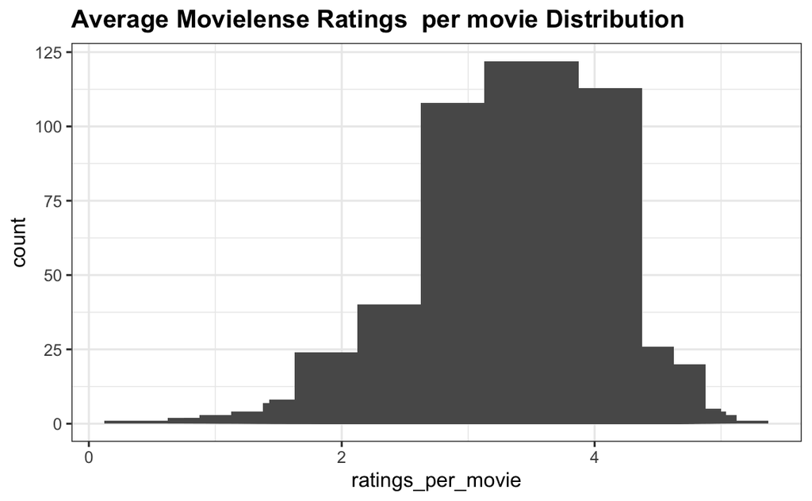

```r
 colMeans(movie_r) %>%
  data.frame(ratings_per_movie = .) %>%
  ggplot(aes(x = ratings_per_movie)) + geom_bar(width = 0.75) +
    labs(title = 'Average Movielense Ratings  per movie Distribution')
```

Here we also explored the genres info, not used for prediction. Need to process string of genres to be used

```r
movie_genre <- as.data.frame(mv_train$genres, stringsAsFactors=FALSE)

movie_genre2 <- as.data.frame(tstrsplit(movie_genre[,1], '[|]',
                                   type.convert=TRUE),
                         stringsAsFactors=FALSE)
#dim(movie_genre2)
colnames(movie_genre2) <- c(1:7)

list_genre <- movie_genre2%>%select(1)%>%distinct()%>%pull()

genre_mat1 <- matrix(0,71802,18)
genre_mat1[1,] <- list_genre
colnames(genre_mat1) <- list_genre

for (index in 1:nrow(movie_genre2)) {
  for (col in 1:ncol(movie_genre2)) {
    gen_col = which(genre_mat1[1,] == movie_genre2[index,col]) #Author DataFlair
    genre_mat1[index+1,gen_col] <- 1
}
}
genre_mat2 <- as.data.frame(genre_mat1[-1,], stringsAsFactors=FALSE) #remove first row, which was the genre list
for (col in 1:ncol(genre_mat2)) {
  genre_mat2[,col] <- as.integer(genre_mat2[,col]) #convert from characters to integers
}
str(genre_mat2)
#keep movie id, title genre to construct the searchmatrix
SearchMatrix <- cbind(mv_train[,1:2], genre_mat2[])
```

3. Train and validate machine learning models:

We would like to use collaborative Filtering, including user-based collaborative filtering and item-based collaborative filtering. We will slipt the data into a training set (80%) and a validation set (20%).

```r
items_to_keep <- 10
rating_threshold <- 3
good_threshold <- 4
set.seed(1)
model_train_scheme <- evaluationScheme(data = movie_r,
                              method = "split",
                         train = 0.8, # proportion of rows to train.
                   given = items_to_keep, # shouldn't keep n rec. items > min(rowCounts(movie_r))
                   goodRating = good_threshold, # for binary classifier analysis.
                   k = 1)
```

We built a random model as a reference

```r
model0 <- getData(model_train_scheme, "train") %>%
  Recommender(method = "RANDOM")

model0_pred <- predict(model0, getData(model_train_scheme, "known"), type = "ratings")
model0_per <- calcPredictionAccuracy(model0_pred, getData(model_train_scheme, "unknown"), byUser = F)
```

First we would use user-based collaborative filtering

```r
model_params <- list(method = "cosine",
                     nn = 10, # find each user's 10 most similar users.
                     sample = FALSE, # already did this.
                     normalize = "center")
model1 <- getData(model_train_scheme, "train") %>%
  Recommender(method = "UBCF", parameter = model_params)

model1_pred <- predict(model1, getData(model_train_scheme, "known"), type = "ratings")
model1_per <- calcPredictionAccuracy(model1_pred, getData(model_train_scheme, "unknown"), byUser = F)
```

second model we used is the item-based collaborative filtering

```r
model_params <- list(method = "cosine",
                     normalize = "center")
model2 <- getData(model_train_scheme, "train") %>%
  Recommender(method = "IBCF", parameter = model_params)

model2_pred <- predict(model2, getData(model_train_scheme, "known"), type = "ratings")
model2_per <- calcPredictionAccuracy(model2_pred, getData(model_train_scheme, "unknown"), byUser = F)
```

Third model we used is the SVD

```r
model_params <- list(normalize = "center")
model3 <- getData(model_train_scheme, "train") %>%
  Recommender(method = "SVD",parameter = model_params)

model3_pred <- predict(model3, getData(model_train_scheme, "known"), type = "ratings")
model3_per <- calcPredictionAccuracy(model3_pred, getData(model_train_scheme, "unknown"), byUser = F)
```

```r
#Fourth model is the SVDF (NOT USED)
# model4 <- getData(model_train_scheme, "train") %>%
#   Recommender(method = "SVDF")
#
# model4_pred <- predict(model4, getData(model_train_scheme, "known"), type = "ratings")
# model4_per <- calcPredictionAccuracy(model4_pred, getData(model_train_scheme, "unknown"), byUser = F)
```

Now we can compare the models

```r
#random
model0_per
```

```
#> RMSE  MSE  MAE
#> 1.85 3.41 1.51
```

```r
#UBCF
model1_per
```

```
#>  RMSE   MSE   MAE
#> 1.190 1.417 0.927
```

```r
#IBCF
model2_per
```

```
#> RMSE  MSE  MAE
#> 1.28 1.63 0.97
```

```r
#SVD
model3_per
```

```
#>  RMSE   MSE   MAE
#> 0.975 0.950 0.741
```

```r
#SVDF
#model4_per
```

4. Model performance

5. Apply the final model to produce movie rating predictions on the test data

```r
# your code here
model_params <- list(normalize = "center")

final_model<-
  movie_r[1:nrow(movie_r)] %>%
  Recommender(method = "SVD", parameter = model_params)


recom <- predict(final_model, movie_r[1:nrow(movie_r)], type = "ratingMatrix")
recom_mat<-as(recom, "matrix")
recom_da<-as.data.frame(recom_mat)

rownames(recom_da)<-rownames(recom_mat)
recom_da<-tibble::rownames_to_column(recom_da, "userId")


head(recom_da)
#convert to long format
recom_dalong<-
  recom_da%>%
  pivot_longer(-userId,names_to = "movieId",values_to = "ratings")

#impute test dataset
test <- select(mv_test, movieId, userId)
rating_predictions<-
  test%>%
  transmute(userId=as.character(userId),
            movieId=as.character(movieId))%>%
  left_join(recom_dalong,by=c("movieId","userId"))%>%
  pull(ratings)

saveRDS(rating_predictions, file = "rating_predictions.RDS")
```